# EDA - Zero to Coke Hero

Ian Donaldson

February 25, 2024

# Introduction

## Business Problem and Analytic Approach

### Business Problem Statement for Swire Coca-Cola’s Innovation Project

#### Business Problem:

Swire Coca-Cola, a prominent leader in the beverage distribution industry across the Western US, faces the challenge of accurately timing the launch of limited edition “innovation” beverage products. Despite possessing extensive historical sales data and regularly introducing new products, Swire struggles with accurately predicting demand for these innovative, never-before-sold items. These products are pivotal for sustaining customer interest, stimulating demand, and maintaining a competitive edge. However, the risk of overproduction or underestimating demand looms, potentially leading to revenue loss or customer dissatisfaction.

#### The Benefit of a Solution:

A precise demand forecast for Swire Coca-Cola’s innovative products is imperative for the company to meet all potential demand without overproducing, thereby maximizing revenue and elevating customer satisfaction. By strategically launching the right products in suitable regions at optimal times, Swire can attain a market advantage, reinforce its position as an industry trendsetter, and foster brand loyalty among increasingly diverse consumers.

#### Success Metrics:

The project’s success will be gauged based on the accuracy of demand forecasts for the specified innovative products compared to actual sales outcomes. Success metrics encompass the model’s capacity to predict location, timing, duration, and units sold for each product launch, furnishing actionable business insights that drive financial gains and amplify market share for essential flavors.

#### Analytics Approach:

The analytics team will employ Exploratory Data Analysis (EDA) to understand the underlying patterns, and utilize various Machine Learning algorithms derived from over 24 million observations spanning three years of sales data. Practically, the team must also grapple with the intricacies of this significant market, which encompasses more than 3100 unique products sold across 13 western states with diverse demographics, while considering the costs associated with production overage and underage. This comprehensive approach aims to predict optimal launch periods for new products and discern the attributes and quantities contributing to successful launches. Additionally, the team will adhere to standard data science practices such as data separation into training and test sets to validate model predictions and accurately forecast demand.

#### Scope:

The project will concentrate on crafting predictive models and generating business insights for seven specified new products. Deliverables include a PowerPoint presentation highlighting key insights, an annotated report delineating the code and model outputs, and all relevant code posted to GitHub for transparency. Future expansions may encompass tailored models for specific brands, locations, or periods to further refine forecasting accuracy.

#### Details:

The project team comprises four analysts: Ian Donaldson, Michael Tom, Andrew Walton, and Jake Jarrard. The project is slated for completion and presentation to the client on April 11, 2024, with key milestones including exploratory data analysis completion by February 25, model building by March 24, and presentation finalization by April 10. This timeline ensures thorough analysis and model development, culminating in a comprehensive presentation of findings to Swire Coca-Cola.

#### Conclusion:

By accurately forecasting demand for innovative limited-release beverages, Swire Coca-Cola can make informed decisions to optimize inventory levels, enhance customer satisfaction, and solidify its position as an industry leader in beverage innovation. The collaborative efforts of the analytics team will furnish Swire with the insights needed to navigate the complexities of new product launches successfully.

## Purpose of Notebook

The purpose of this EDA notebook is to identify and analyze the Swire Coca-Cola data set looking for hints and clues on guidance of forecasting innovation products in a time series format. Additional feature engineering and data cleaning will be performed to prepare the data for time series forecasting and machine learning models.

## Questions about Data to Answer

1. What are the unique features in the data set?
2. What are the data types for each feature?
3. What are the missing values in the data set?
4. Are there unique dates in the data set?
5. Are there unique products in the data set?
6. Are there unique sales territories in the data set?
7. What are Swire’s unqiue innovation products (flavors, packaging, etc)?
8. What are top/bottom selling brands?
9. How do competitors stack up in terms of sales?
10. What seasons are key revenue drivers for Swire?
11. Are there intersting financial metrics?
12. How long do innovation products typically run?
13. How to identify week 0/start/tenure for each innovaiton product?

# Description of the Data

# Discussion of Missing Data

The data set contains NA values for CALORIC_SEGMENT in its raw form comprising 0.2% (59725 missing values) of the data. Using text analysis on ITEM description, imputation was performed to determine the observation’s CALORIC_SEGMENT as either diet/light or regular.

# Exploratory Visualizations and/or Summary Tables

```r
# Load the data
df <- readRDS("~/Documents/R/IS6813/Swire/swire_no_nas.rds")
#write to csv for other tools
#write.csv(df, "swire_no_nas.csv")
```

> Load the data, packages, and set things up.

```r
#season column based on date
df <- df %>%
  mutate(MONTH = month(ymd(df$DATE)), # Extract month from the date
         SEASON = case_when(
           MONTH %in% c(12, 1, 2) ~ "WINTER",
           MONTH %in% c(3, 4, 5) ~ "SPRING",
           MONTH %in% c(6, 7, 8) ~ "SUMMER",
           MONTH %in% c(9, 10, 11) ~ "FALL",
           TRUE ~ NA_character_
         ))

#sales per unit
df <- df %>%
  mutate(SINGLE_PRICE = DOLLAR_SALES / UNIT_SALES)
```

> Months broken up into seasons for potential feature engineering uses, along with sales per unit.

```r
#check df class
class(df)
```

```
## [1] "data.frame"
```

```r
#check df structure
str(df)
```

```
## 'data.frame':    24461424 obs. of  13 variables:
##  $ DATE           : chr  "2021-08-21" "2022-05-07" "2022-10-22" "2022-08-13" ...
##  $ MARKET_KEY     : int  524 637 628 216 210 278 220 499 754 895 ...
##  $ CALORIC_SEGMENT: chr  "DIET/LIGHT" "REGULAR" "DIET/LIGHT" "REGULAR" ...
##  $ CATEGORY       : chr  "SSD" "SSD" "ING ENHANCED WATER" "SSD" ...
##  $ UNIT_SALES     : num  69 4 1 3 4 112 21 3 19 57 ...
##  $ DOLLAR_SALES   : num  389.74 30.96 2.25 7.55 25.96 ...
##  $ MANUFACTURER   : chr  "SWIRE-CC" "COCOS" "JOLLYS" "COCOS" ...
##  $ BRAND          : chr  "DIET YAWN" "GORGEOUS ORANGEOUS" "DIGRESS FLAVORED" "CHERRY FIZZ" ...
##  $ PACKAGE        : chr  "12SMALL 12ONE CUP" "12SMALL 12ONE CUP" "20SMALL MULTI JUG" "1L MULTI JUG" ...
##  $ ITEM           : chr  "YAWN ZERO SUGAR GENTLE DRINK SUPER-JUICE  DURIAN  CUP 12 LIQUID SMALL X12" "GORGEOUS SUNSET OUS GENTLE DRINK AVOCADO  CUP 12 LIQUID SMALL X12" "DIGRESS ZERO NUTRIENT ENHANCED WATER BVRG PURPLE  ZERO CALORIE JUG 20 LIQUID SMALL" "KOOL! RED  GENTLE DRINK RED  COLA CONTOUR …
##  $ MONTH          : num  8 5 10 8 1 11 3 11 7 4 ...
##  $ SEASON         : chr  "SUMMER" "SPRING" "FALL" "SUMMER" ...
##  $ SINGLE_PRICE   : num  5.65 7.74 2.25 2.52 6.49 ...
```

```r
#check df head
head(df)
```

```
##         DATE MARKET_KEY CALORIC_SEGMENT           CATEGORY UNIT_SALES
## 1 2021-08-21        524      DIET/LIGHT                SSD         69
## 2 2022-05-07        637         REGULAR                SSD          4
## 3 2022-10-22        628      DIET/LIGHT ING ENHANCED WATER          1
## 4 2022-08-13        216         REGULAR                SSD          3
## 5 2022-01-01        210         REGULAR                SSD          4
## 6 2021-11-27        278         REGULAR                SSD        112
##   DOLLAR_SALES MANUFACTURER              BRAND           PACKAGE
## 1       389.74     SWIRE-CC          DIET YAWN 12SMALL 12ONE CUP
## 2        30.96        COCOS GORGEOUS ORANGEOUS 12SMALL 12ONE CUP
## 3         2.25       JOLLYS   DIGRESS FLAVORED 20SMALL MULTI JUG
## 4         7.55        COCOS        CHERRY FIZZ      1L MULTI JUG
## 5        25.96        COCOS          RADIANT'S 12SMALL 12ONE CUP
## 6       179.00     SWIRE-CC   ROOT BEER WONDER      2L MULTI JUG
##                                                                                 ITEM
## 1          YAWN ZERO SUGAR GENTLE DRINK SUPER-JUICE  DURIAN  CUP 12 LIQUID SMALL X12
## 2                  GORGEOUS SUNSET OUS GENTLE DRINK AVOCADO  CUP 12 LIQUID SMALL X12
## 3 DIGRESS ZERO NUTRIENT ENHANCED WATER BVRG PURPLE  ZERO CALORIE JUG 20 LIQUID SMALL
## 4                    KOOL! RED  GENTLE DRINK RED  COLA CONTOUR JUG 33.8 LIQUID SMALL
## 5                          RADIANT'S GENTLE DRINK GINGER ALE CUP 12 LIQUID SMALL X12
## 6                          JUMPIN JACKS GENTLE DRINK ROOT BEER JUG 67.6 LIQUID SMALL
##   MONTH SEASON SINGLE_PRICE
## 1     8 SUMMER     5.648406
## 2     5 SPRING     7.740000
## 3    10   FALL     2.250000
## 4     8 SUMMER     2.516667
## 5     1 WINTER     6.490000
## 6    11   FALL     1.598214
```

```r
#NAs
sum(is.na(df))
```

```
## [1] 0
```

```r
#skim df
skim(df)
```

Data summary

| Name | df |
| --- | --- |
| Number of rows | 24461424 |
| Number of columns | 13 |
| _______________________ |  |
| Column type frequency: |  |
| character | 8 |
| numeric | 5 |
| ________________________ |  |
| Group variables | None |

**Variable type: character**

| skim_variable | n_missing | complete_rate | min | max | empty | n_unique | whitespace |
| --- | --- | --- | --- | --- | --- | --- | --- |
| DATE | 0 | 1 | 10 | 10 | 0 | 152 | 0 |
| CALORIC_SEGMENT | 0 | 1 | 7 | 10 | 0 | 2 | 0 |
| CATEGORY | 0 | 1 | 3 | 18 | 0 | 5 | 0 |
| MANUFACTURER | 0 | 1 | 5 | 8 | 0 | 8 | 0 |
| BRAND | 0 | 1 | 4 | 56 | 0 | 319 | 0 |
| PACKAGE | 0 | 1 | 11 | 26 | 0 | 103 | 0 |
| ITEM | 0 | 1 | 26 | 142 | 0 | 3692 | 0 |
| SEASON | 0 | 1 | 4 | 6 | 0 | 4 | 0 |

**Variable type: numeric**

| skim_variable | n_missing | complete_rate | mean | sd | p0 | p25 | p50 | p75 | p100 | hist |
| --- | --- | --- | --- | --- | --- | --- | --- | --- | --- | --- |
| MARKET_KEY | 0 | 1 | 593.14 | 605.88 | 1.00 | 260.00 | 547.00 | 845.00 | 6802.00 | ▇▁▁▁▁ |
| UNIT_SALES | 0 | 1 | 174.37 | 857.81 | 0.04 | 11.00 | 40.00 | 126.00 | 96776.00 | ▇▁▁▁▁ |
| DOLLAR_SALES | 0 | 1 | 591.14 | 3040.54 | 0.01 | 36.59 | 135.05 | 427.14 | 492591.07 | ▇▁▁▁▁ |
| MONTH | 0 | 1 | 6.28 | 3.43 | 1.00 | 3.00 | 6.00 | 9.00 | 12.00 | ▇▆▆▅▇ |
| SINGLE_PRICE | 0 | 1 | 4.53 | 4.79 | 0.00 | 2.00 | 3.18 | 5.34 | 224.99 | ▇▁▁▁▁ |

> There are 59725 missing values in the original dataset. After imputing NAs based on text data (seperate steps from Jake), we are left with 0 missing values. Many features are characters and should be converted to factors. The data is not duplicated. We have 152 unique DATEs (weeks) in the data set, which indicates that there is weekly data for nearly 3 years without any fulling missing weeks. There are 2 CALORIC_SEGMENTS, diet and regular;5 CATEGORIES; 8 MANUFACTURERS; 319 BRANDS; 103 PACKAGE types; 3692 unique ITEM descriptions.

```r
#convert date to date type
df$DATE <- as.Date(df$DATE)



#factorize
df <- df %>%
  mutate(BRAND = as.character(BRAND),
         PACKAGE = as.character(PACKAGE)) %>%
  mutate(across(c(BRAND, PACKAGE, CATEGORY, MANUFACTURER, SEASON), ~as.factor(.)))


#one hot encode CALORIC_SEGMENT as 0 or 1
df <- df %>%
mutate(across(CALORIC_SEGMENT, ~ifelse(. == "REGULAR", 1, 0)))


# Print the result
#validate data types
summary(df)
```

```
##       DATE              MARKET_KEY     CALORIC_SEGMENT
##  Min.   :2020-12-05   Min.   :   1.0   Min.   :0.0000
##  1st Qu.:2021-08-14   1st Qu.: 260.0   1st Qu.:0.0000
##  Median :2022-04-23   Median : 547.0   Median :1.0000
##  Mean   :2022-04-25   Mean   : 593.1   Mean   :0.5023
##  3rd Qu.:2022-12-31   3rd Qu.: 845.0   3rd Qu.:1.0000
##  Max.   :2023-10-28   Max.   :6802.0   Max.   :1.0000
##
##                CATEGORY          UNIT_SALES        DOLLAR_SALES
##  COFFEE            :  145536   Min.   :    0.04   Min.   :     0.0
##  ENERGY            : 5932087   1st Qu.:   11.00   1st Qu.:    36.6
##  ING ENHANCED WATER: 2452456   Median :   40.00   Median :   135.1
##  SPARKLING WATER   : 3019064   Mean   :  174.37   Mean   :   591.1
##  SSD               :12912281   3rd Qu.:  126.00   3rd Qu.:   427.1
##                                Max.   :96776.00   Max.   :492591.1
##
##    MANUFACTURER                         BRAND
##  JOLLYS  :6921978   CROWN                  : 1239010
##  SWIRE-CC:5763809   REAL-TIME EDITIONS     :  827868
##  COCOS   :5595540   DIGRESS FLAVORED       :  731199
##  PONYS   :2259095   MYTHICAL BEVERAGE ULTRA:  718536
##  BEARS   :1593430   BUBBLE JOY             :  535030
##  ALLYS   :1428416   REAL-TIME              :  531911
##  (Other) : 899156   (Other)                :19877870
##               PACKAGE             ITEM               MONTH
##  16SMALL MULTI CUP: 3065844   Length:24461424    Min.   : 1.000
##  20SMALL MULTI JUG: 2877015   Class :character   1st Qu.: 3.000
##  12SMALL 12ONE CUP: 2870763   Mode  :character   Median : 6.000
##  2L MULTI JUG     : 1896248                      Mean   : 6.284
##  .5L 6ONE JUG     : 1453399                      3rd Qu.: 9.000
##  12SMALL 8ONE CUP : 1408738                      Max.   :12.000
##  (Other)          :10889417
##     SEASON         SINGLE_PRICE
##  FALL  :5215034   Min.   :  0.00333
##  SPRING:6668574   1st Qu.:  2.00429
##  SUMMER:6164348   Median :  3.18000
##  WINTER:6413468   Mean   :  4.52689
##                   3rd Qu.:  5.34105
##                   Max.   :224.99000
##
```

> After feature data type conversion, the data is ready for exploratory data analysis.

```r
#echo BRAND name and spacing
cat("\n DIET SMASH \n")
```

```
##
##  DIET SMASH
```

```r
#BRAND == DIET SMASH
df %>%
  filter(BRAND == "DIET SMASH") %>%
  select(MANUFACTURER,CALORIC_SEGMENT, CATEGORY, PACKAGE, ) %>%
  summary()
```

```
##    MANUFACTURER   CALORIC_SEGMENT               CATEGORY
##  SWIRE-CC:17483   Min.   :0       COFFEE            :    0
##  ALLYS   :    0   1st Qu.:0       ENERGY            :    0
##  BEARS   :    0   Median :0       ING ENHANCED WATER:    0
##  COCOS   :    0   Mean   :0       SPARKLING WATER   :    0
##  JOLLYS  :    0   3rd Qu.:0       SSD               :17483
##  JORDYS  :    0   Max.   :0
##  (Other) :    0
##               PACKAGE
##  12SMALL 12ONE CUP:11849
##  2L MULTI JUG     : 5630
##  12SMALL 6ONE CUP :    4
##  .5L 12ONE JUG    :    0
##  .5L 24ONE JUG    :    0
##  .5L 4ONE JUG     :    0
##  (Other)          :    0
```

```r
#echo BRAND name and spacing
cat("\n SPARKLING JACCEPTABLETLESTER \n")
```

```
##
##  SPARKLING JACCEPTABLETLESTER
```

```r
#BRAND == JACCEPTABLETESTER
df %>%
  filter(BRAND == "SPARKLING JACCEPTABLETLESTER") %>%
  select(MANUFACTURER,CALORIC_SEGMENT, CATEGORY, PACKAGE) %>%
  summary()
```

```
##    MANUFACTURER    CALORIC_SEGMENT                CATEGORY
##  SWIRE-CC:299697   Min.   :0.0000   COFFEE            :     0
##  ALLYS   :     0   1st Qu.:0.0000   ENERGY            :     0
##  BEARS   :     0   Median :1.0000   ING ENHANCED WATER:     0
##  COCOS   :     0   Mean   :0.7275   SPARKLING WATER   : 81682
##  JOLLYS  :     0   3rd Qu.:1.0000   SSD               :218015
##  JORDYS  :     0   Max.   :1.0000
##  (Other) :     0
##                       PACKAGE
##  1L MULTI JUG             :65127
##  ALL OTHER ONES           :52678
##  7.5SMALL 6ONE CUP        :50855
##  10SMALL 6ONE PLASTICS JUG:35845
##  2L MULTI JUG             :27326
##  20SMALL MULTI JUG        :27106
##  (Other)                  :40760
```

```r
#echo BRAND name and spacing
cat("\n VENOMOUS BLAST \n")
```

```
##
##  VENOMOUS BLAST
```

```r
#BRAND == VENOMOUS BLAST
df %>%
  filter(BRAND == "VENOMOUS BLAST") %>%
  select(MANUFACTURER,CALORIC_SEGMENT, CATEGORY, PACKAGE) %>%
  summary()
```

```
##    MANUFACTURER   CALORIC_SEGMENT                CATEGORY
##  SWIRE-CC:51756   Min.   :0.0000   COFFEE            :    0
##  ALLYS   :    0   1st Qu.:0.0000   ENERGY            :51756
##  BEARS   :    0   Median :1.0000   ING ENHANCED WATER:    0
##  COCOS   :    0   Mean   :0.7449   SPARKLING WATER   :    0
##  JOLLYS  :    0   3rd Qu.:1.0000   SSD               :    0
##  JORDYS  :    0   Max.   :1.0000
##  (Other) :    0
##               PACKAGE
##  16SMALL MULTI CUP:51728
##  8SMALL MULTI CUP :   19
##  16SMALL MULTI JUG:    9
##  .5L 12ONE JUG    :    0
##  .5L 24ONE JUG    :    0
##  .5L 4ONE JUG     :    0
##  (Other)          :    0
```

```r
#echo BRAND name and spacing
cat("\n SQUARE \n")
```

```
##
##  SQUARE
```

```r
#BRAND == SQUARE
df %>%
  filter(BRAND == "SQUARE") %>%
  select(MANUFACTURER,CALORIC_SEGMENT, CATEGORY, PACKAGE) %>%
  summary()
```

```
##    MANUFACTURER  CALORIC_SEGMENT                CATEGORY
##  SWIRE-CC:7017   Min.   :0.0000   COFFEE            :   0
##  ALLYS   :   0   1st Qu.:1.0000   ENERGY            :   0
##  BEARS   :   0   Median :1.0000   ING ENHANCED WATER:   0
##  COCOS   :   0   Mean   :0.7881   SPARKLING WATER   :7015
##  JOLLYS  :   0   3rd Qu.:1.0000   SSD               :   2
##  JORDYS  :   0   Max.   :1.0000
##  (Other) :   0
##                 PACKAGE
##  20SMALL MULTI JUG  :6641
##  ALL OTHER ONES     : 347
##  2L MULTI JUG       :  27
##  .5L MLT SHADYES JUG:   1
##  1.5L MULTI JUG     :   1
##  .5L 12ONE JUG      :   0
##  (Other)            :   0
```

```r
#echo BRAND name and spacing
cat("\n GREETINGLE \n")
```

```
##
##  GREETINGLE
```

```r
#BRAND == GREETINGLE
df %>%
  filter(BRAND == "GREETINGLE") %>%
  select(MANUFACTURER,CALORIC_SEGMENT, CATEGORY, PACKAGE) %>%
  summary()
```

```
##    MANUFACTURER    CALORIC_SEGMENT               CATEGORY
##  SWIRE-CC:491300   Min.   :0       COFFEE            :     0
##  ALLYS   :     0   1st Qu.:0       ENERGY            :     0
##  BEARS   :     0   Median :0       ING ENHANCED WATER:491300
##  COCOS   :     0   Mean   :0       SPARKLING WATER   :     0
##  JOLLYS  :     0   3rd Qu.:0       SSD               :     0
##  JORDYS  :     0   Max.   :0
##  (Other) :     0
##               PACKAGE
##  18SMALL MULTI JUG:373131
##  18SMALL 6ONE     : 86750
##  .5L 6ONE JUG     : 23207
##  ALL OTHER ONES   :  7845
##  .5L 12ONE JUG    :   367
##  .5L 24ONE JUG    :     0
##  (Other)          :     0
```

```r
#echo BRAND name and spacing
cat("\n DIET MOONLIT \n")
```

```
##
##  DIET MOONLIT
```

```r
#BRAND == DIET MOONLIT
df %>%
  filter(BRAND == "DIET MOONLIT") %>%
  select(MANUFACTURER,CALORIC_SEGMENT, CATEGORY, PACKAGE) %>%
  summary()
```

```
##    MANUFACTURER   CALORIC_SEGMENT               CATEGORY
##  SWIRE-CC:75948   Min.   :0       COFFEE            :    0
##  ALLYS   :    0   1st Qu.:0       ENERGY            :    0
##  BEARS   :    0   Median :0       ING ENHANCED WATER:    0
##  COCOS   :    0   Mean   :0       SPARKLING WATER   :    0
##  JOLLYS  :    0   3rd Qu.:0       SSD               :75948
##  JORDYS  :    0   Max.   :0
##  (Other) :    0
##               PACKAGE
##  2L MULTI JUG     :28140
##  12SMALL 12ONE CUP:28006
##  .5L 6ONE JUG     :12023
##  20SMALL MULTI JUG: 7684
##  12SMALL 6ONE CUP :   94
##  ALL OTHER ONES   :    1
##  (Other)          :    0
```

```r
#echo BRAND name and spacing
cat("\n PEPPY \n")
```

```
##
##  PEPPY
```

```r
#BRAND == PEPPY
df %>%
  filter(BRAND == "PEPPY") %>%
  select(MANUFACTURER,CALORIC_SEGMENT, CATEGORY, PACKAGE) %>%
  summary()
```

```
##    MANUFACTURER    CALORIC_SEGMENT               CATEGORY
##  SWIRE-CC:399458   Min.   :1       COFFEE            :     0
##  ALLYS   :     0   1st Qu.:1       ENERGY            :     0
##  BEARS   :     0   Median :1       ING ENHANCED WATER:     0
##  COCOS   :     0   Mean   :1       SPARKLING WATER   :     0
##  JOLLYS  :     0   3rd Qu.:1       SSD               :399458
##  JORDYS  :     0   Max.   :1
##  (Other) :     0
##               PACKAGE
##  20SMALL MULTI JUG: 34546
##  2L MULTI JUG     : 29397
##  .5L 6ONE JUG     : 29396
##  12SMALL 12ONE CUP: 29396
##  7.5SMALL 6ONE CUP: 29389
##  1L MULTI JUG     : 29300
##  (Other)          :218034
```

```r
# Turn off scientific notation
options(scipen = 999)


#sales in thousands by manufacturer
df %>%
  group_by(MANUFACTURER) %>%
  summarise(TOTAL_SALES = sum(DOLLAR_SALES)) %>%
  arrange(desc(TOTAL_SALES))
```

```
## # A tibble: 8 × 2
##   MANUFACTURER TOTAL_SALES
##   <fct>              <dbl>
## 1 COCOS        4563306476.
## 2 JOLLYS       3301641671.
## 3 SWIRE-CC     2885435787.
## 4 ALLYS        1562675378.
## 5 PONYS        1481611289.
## 6 BEARS         312718094.
## 7 JORDYS        209238104.
## 8 KEKES         143501825.
```

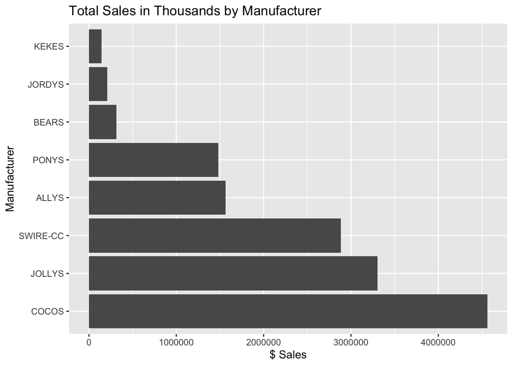

```r
#graph sales in thousands by manufacturer

df %>%
  group_by(MANUFACTURER) %>%
  summarise(TOTAL_SALES = sum(DOLLAR_SALES/1000)) %>%
  ggplot(aes(x = reorder(MANUFACTURER, -TOTAL_SALES), y = TOTAL_SALES)) +
  geom_col() +
  coord_flip() +
  labs(title = "Total Sales in Thousands by Manufacturer",
       x = "Manufacturer",
       y = "$ Sales")
```

```r
#sales in thousands by top 10 package size
df %>%
  group_by(PACKAGE) %>%
  summarise(TOTAL_SALES = sum(DOLLAR_SALES/1000)) %>%
  arrange(desc(TOTAL_SALES)) %>%
  head(10)
```

```
## # A tibble: 10 × 2
##    PACKAGE                  TOTAL_SALES
##    <fct>                          <dbl>
##  1 12SMALL 12ONE CUP           3422060.
##  2 20SMALL MULTI JUG           1814841.
##  3 16SMALL MULTI CUP           1621832.
##  4 .5L 6ONE JUG                1089477.
##  5 12SMALL 24ONE CUP           1007780.
##  6 2L MULTI JUG                 830755.
##  7 12SMALL MULTI CUP            758168.
##  8 12SMALL 8ONE CUP             422976.
##  9 ALL OTHER ONES               291378.
## 10 12SMALL 8ONE SHADYES JUG     274115.
```

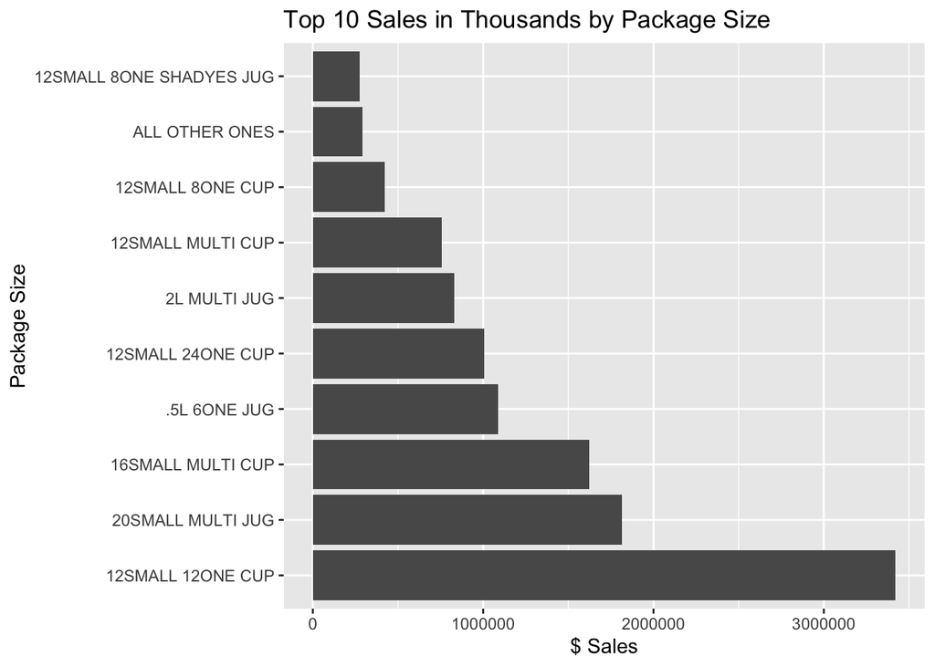

```r
#graph sales in thousands by top 10 ten package size
df %>%
  group_by(PACKAGE) %>%
  summarise(TOTAL_SALES = sum(DOLLAR_SALES/1000)) %>%
  arrange(desc(TOTAL_SALES)) %>%
  head(10) %>%
  ggplot(aes(x = reorder(PACKAGE, -TOTAL_SALES), y = TOTAL_SALES)) +
  geom_col() +
  coord_flip() +
  labs(title = "Top 10 Sales in Thousands by Package Size",
       x = "Package Size",
       y = "$ Sales")
```

```r
#bottom 10 sales in throusands by package size
df %>%
  group_by(PACKAGE) %>%
  summarise(TOTAL_SALES = sum(DOLLAR_SALES)) %>%
  arrange(TOTAL_SALES) %>%
  head(10)
```

```
## # A tibble: 10 × 2
##    PACKAGE                    TOTAL_SALES
##    <fct>                            <dbl>
##  1 8.55SMALL MLT SHADYES JUG         2.1
##  2 20SMALL 15ONE JUG                 6.49
##  3 8.55SMALL 6ONE SHADYES JUG        8
##  4 24SMALL 4ONE JUG                  9.94
##  5 .5L 4ONE JUG                     17.3
##  6 1L 12ONE JUG                     18.5
##  7 12SMALL 8ONE JUG                 27.3
##  8 20SMALL 12ONE SHADYES JUG        30.0
##  9 12SMALL 32ONE CUP                35.5
## 10 16SMALL MULTI JUG                36.7
```

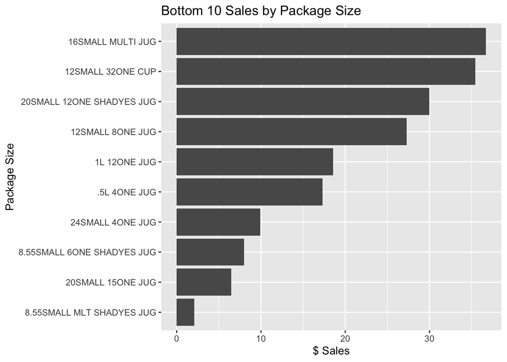

```r
#graph sales in thousands by bottom 10 package size
df %>%
  group_by(PACKAGE) %>%
  summarise(TOTAL_SALES = sum(DOLLAR_SALES)) %>%
  arrange(TOTAL_SALES) %>%
  head(10) %>%
  ggplot(aes(x = reorder(PACKAGE, TOTAL_SALES), y = TOTAL_SALES)) +
  geom_col() +
  coord_flip() +
  labs(title = "Bottom 10 Sales by Package Size",
       x = "Package Size",
       y = "$ Sales")
```

```r
#top 10 sales in thousands by brand
df %>%
  group_by(BRAND) %>%
  summarise(TOTAL_SALES = sum(DOLLAR_SALES/1000)) %>%
  arrange(desc(TOTAL_SALES)) %>%
  head(10)
```

```
## # A tibble: 10 × 2
##    BRAND                        TOTAL_SALES
##    <fct>                              <dbl>
##  1 BUBBLE JOY ADVANTAGEOUS         1604867.
##  2 REAL-TIME                       1037072.
##  3 PEPPY                            937030.
##  4 PAPI                             816414.
##  5 DIET BUBBLE JOY ADVANTAGEOUS     653091.
##  6 ELF BUBBLES                      649144.
##  7 HILL MOISTURE                    557565.
##  8 REAL-TIME EDITIONS               514215.
##  9 MYTHICAL BEVERAGE ULTRA          499398.
## 10 MYTHICAL BEVERAGE                462803.
```

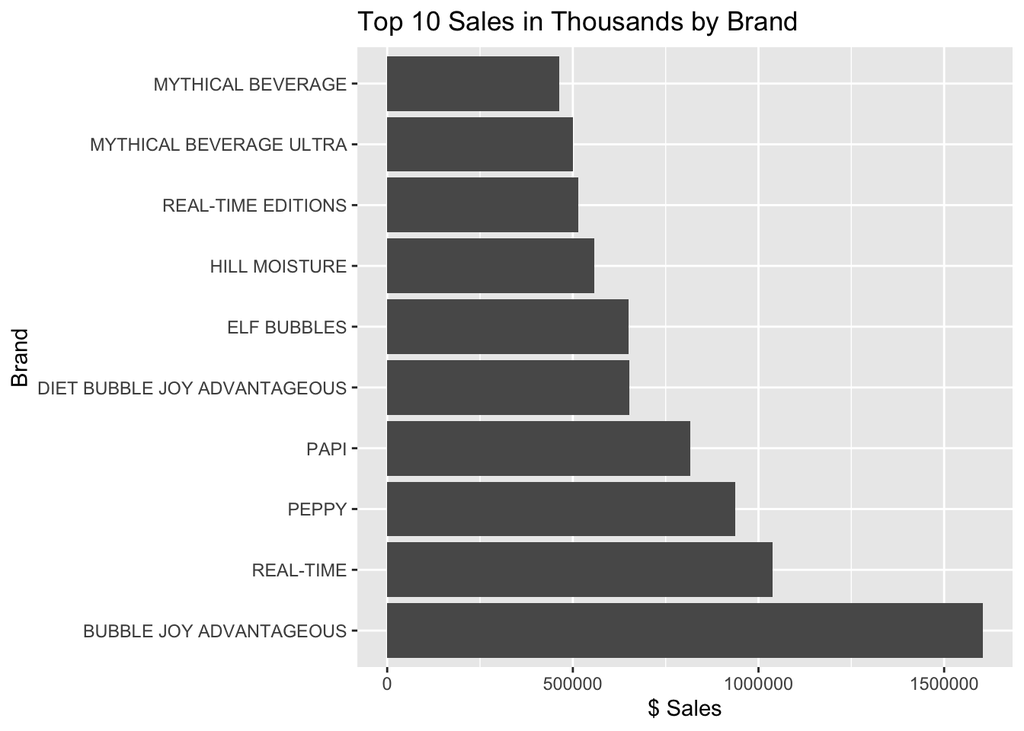

```r
#graph sales in thousands by top 10 brand
df %>%
  group_by(BRAND) %>%
  summarise(TOTAL_SALES = sum(DOLLAR_SALES/1000)) %>%
  arrange(desc(TOTAL_SALES)) %>%
  head(10) %>%
  ggplot(aes(x = reorder(BRAND, -TOTAL_SALES), y = TOTAL_SALES)) +
  geom_col() +
  coord_flip() +
  labs(title = "Top 10 Sales in Thousands by Brand",
       x = "Brand",
       y = "$ Sales")
```

```r
#bottom 10 sales in thousands by brand
df %>%
  group_by(BRAND) %>%
  summarise(TOTAL_SALES = sum(DOLLAR_SALES)) %>%
  arrange(TOTAL_SALES) %>%
  head(10)
```

```
## # A tibble: 10 × 2
##    BRAND                                       TOTAL_SALES
##    <fct>                                             <dbl>
##  1 MIST TWST NAT CBRY                                 0.99
##  2 TIPCAL CANARY TWISTER SODA                         1.19
##  3 VAULTLESS                                          1.69
##  4 DIET MIST TWST MIXED-FRUIT                         2
##  5 ONLY ORGANIC                                       2.29
##  6 DIET BUBBLE JOY ADVANTAGEOUS BLUEBERRY ACAI        2.86
##  7 SUPER-DUPER SPARKLING                              4.5
##  8 GORGEOUS ORANGEOUS CHERRY                          5.05
##  9 MAXIMUM RED BERRY                                  5.68
## 10 PAPI CHRY/VAN REAL SUGAR                           5.97
```

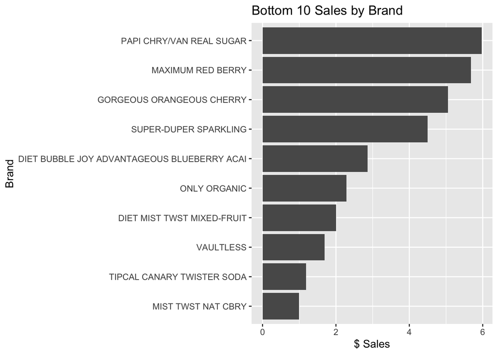

```r
#graph sales in thousands by bottom 10 brand
df %>%
  group_by(BRAND) %>%
  summarise(TOTAL_SALES = sum(DOLLAR_SALES)) %>%
  arrange(TOTAL_SALES) %>%
  head(10) %>%
  ggplot(aes(x = reorder(BRAND, TOTAL_SALES), y = TOTAL_SALES)) +
  geom_col() +
  coord_flip() +
  labs(title = "Bottom 10 Sales by Brand",
       x = "Brand",
       y = "$ Sales")
```

```r
#sales in thousands by category
df %>%
  group_by(CATEGORY) %>%
  summarise(TOTAL_SALES = sum(DOLLAR_SALES/1000)) %>%
  arrange(desc(TOTAL_SALES))
```

```
## # A tibble: 5 × 2
##   CATEGORY           TOTAL_SALES
##   <fct>                    <dbl>
## 1 SSD                   9606515.
## 2 ENERGY                3718445.
## 3 SPARKLING WATER        626470.
## 4 ING ENHANCED WATER     494293.
## 5 COFFEE                  14405.
```

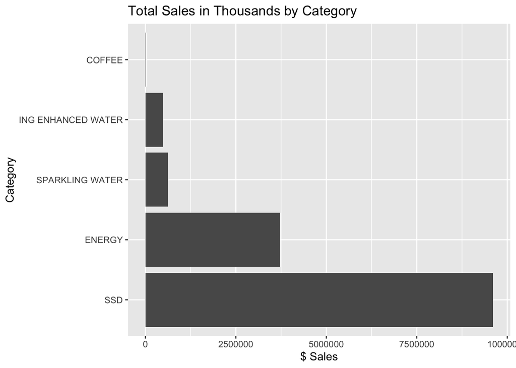

```r
#graph sales in thousands by CATEGORY
df %>%
  group_by(CATEGORY) %>%
  summarise(TOTAL_SALES = sum(DOLLAR_SALES/1000)) %>%
  ggplot(aes(x = reorder(CATEGORY, -TOTAL_SALES), y = TOTAL_SALES)) +
  geom_col() +
  coord_flip() +
  labs(title = "Total Sales in Thousands by Category",
       x = "Category",
       y = "$ Sales")
```

```r
#sales in thousands by season
df %>%
  group_by(SEASON) %>%
  summarise(TOTAL_SALES = sum(DOLLAR_SALES/1000)) %>%
  arrange(desc(TOTAL_SALES))
```

```
## # A tibble: 4 × 2
##   SEASON TOTAL_SALES
##   <fct>        <dbl>
## 1 SPRING    3874929.
## 2 SUMMER    3865217.
## 3 WINTER    3616622.
## 4 FALL      3103362.
```

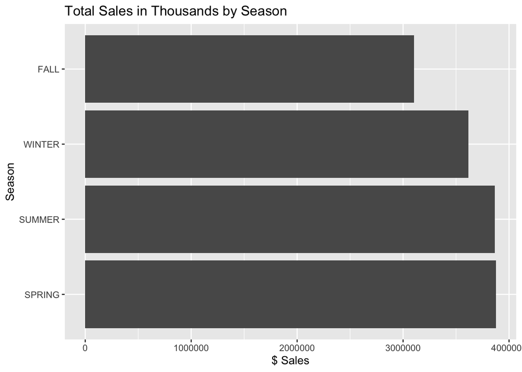

```r
#graph sales by SEASON
df %>%
  group_by(SEASON) %>%
  summarise(TOTAL_SALES = sum(DOLLAR_SALES/1000)) %>%
  ggplot(aes(x = reorder(SEASON, -TOTAL_SALES), y = TOTAL_SALES)) +
  geom_col() +
  coord_flip() +
  labs(title = "Total Sales in Thousands by Season",
       x = "Season",
       y = "$ Sales")
```

```r
#top 10 longest running brands
df %>%
  group_by(BRAND) %>%
  summarise(LENGTH = n_distinct(DATE)) %>%
  arrange(desc(LENGTH)) %>%
  head(10)
```

```
## # A tibble: 10 × 2
##    BRAND                        LENGTH
##    <fct>                         <int>
##  1 CARBONATE STREAM                152
##  2 CUPADA ARID                     152
##  3 RADIANT'S                       152
##  4 SINGLE GROUP                    152
##  5 SPARKLING JACCEPTABLETLESTER    152
##  6 BUBBLE JOY                      148
##  7 CARBONATE STREAM WATERS         148
##  8 CROWN                           148
##  9 DIGRESS FLAVORED                148
## 10 EXCLAMATION SODA                148
```

```r
#shortest 10 running brands
df %>%
  group_by(BRAND) %>%
  summarise(LENGTH = n_distinct(DATE)) %>%
  arrange(LENGTH) %>%
  head(10)
```

```
## # A tibble: 10 × 2
##    BRAND                                                LENGTH
##    <fct>                                                 <int>
##  1 LAUGHING MYTHICAL BEVERAGE CHAI HAI                       1
##  2 MIST TWST NAT CBRY                                        1
##  3 ONLY ORGANIC                                              1
##  4 PAPI VANILLA REAL SUGAR                                   1
##  5 TIPCAL CANARY TWISTER SODA                                1
##  6 VAULTLESS                                                 1
##  7 DIET BUBBLE JOY ADVANTAGEOUS BLUEBERRY ACAI               2
##  8 DIET BUBBLE JOY ADVANTAGEOUS PLANT-BASED SWEENTENERS      2
##  9 DIET MIST TWST MIXED-FRUIT                                2
## 10 DIET MUTANT                                               2
```

```r
#median length of time for a brand
df %>%
  group_by(BRAND) %>%
  summarise(LENGTH = n_distinct(DATE)) %>%
  summarise(median(LENGTH))
```

```
## # A tibble: 1 × 1
##   `median(LENGTH)`
##              <int>
## 1              137
```

```r
#mean length of time for a brand
df %>%
  group_by(BRAND) %>%
  summarise(LENGTH = n_distinct(DATE)) %>%
  summarise(mean(LENGTH))
```

```
## # A tibble: 1 × 1
##   `mean(LENGTH)`
##            <dbl>
## 1           99.1
```

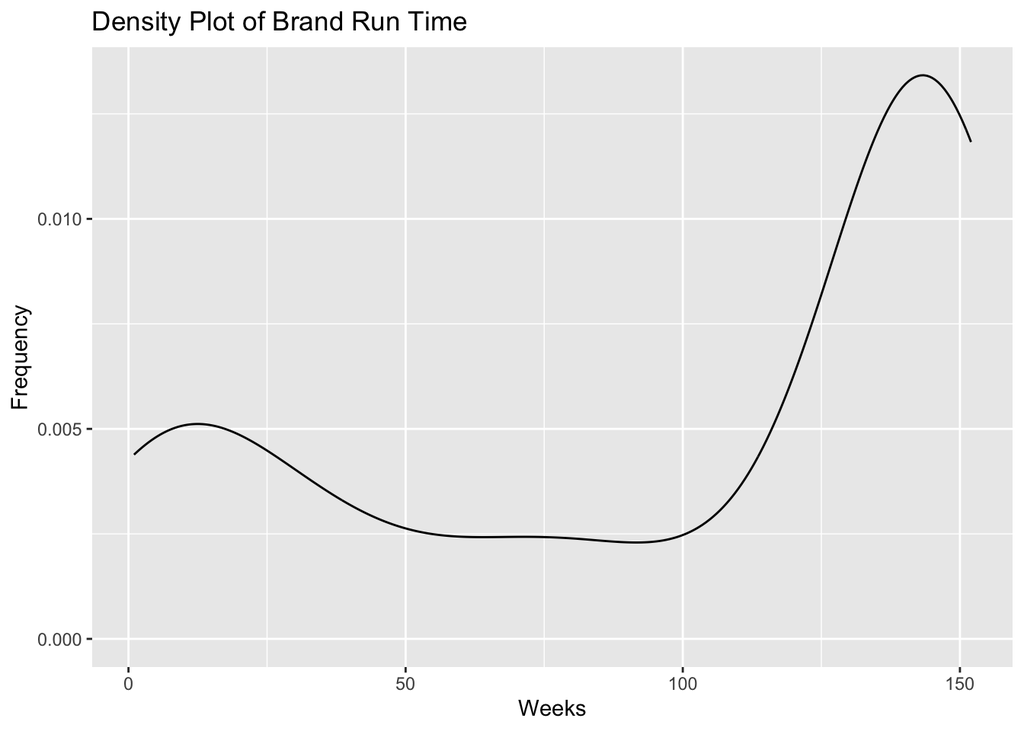

```r
#density plot of brand run time
df %>%
  group_by(BRAND) %>%
  summarise(LENGTH = n_distinct(DATE)) %>%
  ggplot(aes(x = LENGTH)) +
  geom_density() +
  labs(title = "Density Plot of Brand Run Time",
       x = "Weeks",
       y = "Frequency")
```

```r
#brands that run for less than 6 months
df %>%
  group_by(BRAND) %>%
  summarise(LENGTH = n_distinct(DATE)) %>%
  filter(LENGTH < 26)
```

```
## # A tibble: 63 × 2
##    BRAND                                                LENGTH
##    <fct>                                                 <int>
##  1 BARS                                                      4
##  2 BUBBLE JOY ADVANTAGEOUS W/LIME                           14
##  3 CLEAR RADIANCE PAPI                                      24
##  4 CUPADA ARID REMAINING                                    24
##  5 DIET BUBBLE JOY ADVANTAGEOUS BLUEBERRY ACAI               2
##  6 DIET BUBBLE JOY ADVANTAGEOUS PLANT-BASED SWEENTENERS      2
##  7 DIET BUBBLE JOY ADVANTAGEOUS STRAWBERRY GUAVA             3
##  8 DIET BUBBLE JOY ADVANTAGEOUS W/LIME                      21
##  9 DIET DROPTOP                                             10
## 10 DIET HILL MOISTURE ELECTRICITY                           21
## # ℹ 53 more rows
```

```r
#summarize features of brands that run for less than 6 months
df %>%
  group_by(BRAND) %>%
  summarise(LENGTH = n_distinct(DATE)) %>%
  filter(LENGTH < 6) %>%
  left_join(df, by = "BRAND") %>%
  select(BRAND, CATEGORY, SEASON, PACKAGE, MANUFACTURER) %>%
  distinct()
```

```
## # A tibble: 61 × 5
##    BRAND                                    CATEGORY SEASON PACKAGE MANUFACTURER
##    <fct>                                    <fct>    <fct>  <fct>   <fct>
##  1 BARS                                     SSD      FALL   2L MUL… COCOS
##  2 DIET BUBBLE JOY ADVANTAGEOUS BLUEBERRY … SSD      SUMMER 12SMAL… COCOS
##  3 DIET BUBBLE JOY ADVANTAGEOUS BLUEBERRY … SSD      WINTER 12SMAL… COCOS
##  4 DIET BUBBLE JOY ADVANTAGEOUS PLANT-BASE… SSD      SUMMER 7.5SMA… COCOS
##  5 DIET BUBBLE JOY ADVANTAGEOUS STRAWBERRY… SSD      SPRING 12SMAL… COCOS
##  6 DIET BUBBLE JOY ADVANTAGEOUS STRAWBERRY… SSD      WINTER 12SMAL… COCOS
##  7 DIET BUBBLE JOY ADVANTAGEOUS STRAWBERRY… SSD      WINTER 12SMAL… COCOS
##  8 DIET MIST TWST MIXED-FRUIT               SSD      WINTER 2L MUL… JOLLYS
##  9 DIET MIST TWST MIXED-FRUIT               SSD      SUMMER 2L MUL… JOLLYS
## 10 DIET MUTANT                              SSD      SPRING 20SMAL… PONYS
## # ℹ 51 more rows
```

> The top 10 brands that run 148 or 152 weeks do not include some of the top sales by brands (are there missing weeks?). The top 10 shortest running brands include bottom brands by sales and only ran for 1 or two weeks, which makes sense if something only registered one single sale. The median length of a brand is 137 weeks, with mean brand run time falling in a 99.1 weeks. Therefore, the data likely exhibits left skewness, indicating that there are some brands with very short run times (which pull down the mean), while the median is higher due to the influence of some brands with longer run times. The histogram of brand run time shows a left skew with several stalwart brands running for a very long time, and a lot of brands, including innovation types, running for a shorter duration. As can be seen in the density plot there are two main humps or modes, one that clusters between 0 and ~25 weeks (6 months) trending down to a flatter line between week 50 and week 100, and another much larger cluster presumably dominated by the always on the shlef types cluster between 125 and 152 weeks. It may be worth looking for week 0/launch/tenure date spikes for those products that runs less than 6 months in order to determine start/stop times for any ARIMA/Time-Series models later.

```r
#top 10 longest running packages
df %>%
  group_by(PACKAGE) %>%
  summarise(LENGTH = n_distinct(DATE)) %>%
  arrange(desc(LENGTH)) %>%
  head(10)
```

```
## # A tibble: 10 × 2
##    PACKAGE           LENGTH
##    <fct>              <int>
##  1 .5L 12ONE JUG        152
##  2 .5L 24ONE JUG        152
##  3 .5L 6ONE JUG         152
##  4 12SMALL 12ONE CUP    152
##  5 12SMALL 15ONE CUP    152
##  6 12SMALL 24ONE CUP    152
##  7 12SMALL 6ONE CUP     152
##  8 16SMALL MULTI CUP    152
##  9 1L MULTI JUG         152
## 10 20SMALL 24ONE JUG    152
```

```r
#shortest 10 running packages
df %>%
  group_by(PACKAGE) %>%
  summarise(LENGTH = n_distinct(DATE)) %>%
  arrange(LENGTH) %>%
  head(10)
```

```
## # A tibble: 10 × 2
##    PACKAGE                    LENGTH
##    <fct>                       <int>
##  1 1L 12ONE JUG                    1
##  2 20SMALL 15ONE JUG               1
##  3 8.55SMALL 6ONE SHADYES JUG      1
##  4 24SMALL 4ONE JUG                2
##  5 20SMALL 12ONE SHADYES JUG       3
##  6 8.55SMALL MLT SHADYES JUG       3
##  7 .5L 4ONE JUG                    5
##  8 12SMALL 32ONE CUP               6
##  9 12SMALL 8ONE JUG                6
## 10 .5L 8ONE SHADYES JUG            7
```

```r
#median length of time for a package
df %>%
  group_by(PACKAGE) %>%
  summarise(LENGTH = n_distinct(DATE)) %>%
  summarise(median(LENGTH))
```

```
## # A tibble: 1 × 1
##   `median(LENGTH)`
##              <int>
## 1              147
```

```r
#mean length of time for a package
df %>%
  group_by(PACKAGE) %>%
  summarise(LENGTH = n_distinct(DATE)) %>%
  summarise(mean(LENGTH))
```

```
## # A tibble: 1 × 1
##   `mean(LENGTH)`
##            <dbl>
## 1           117.
```

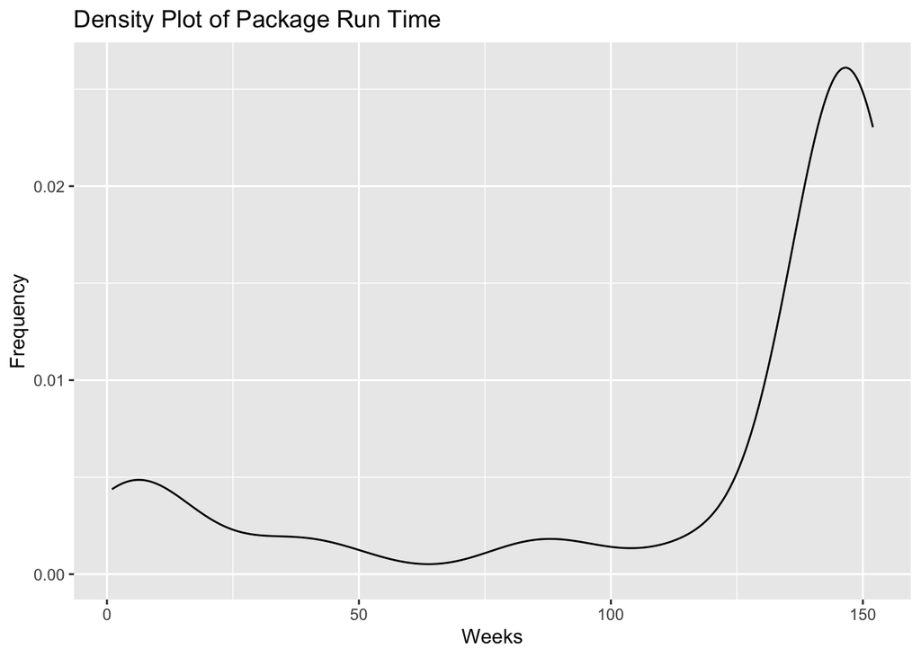

```r
#density plot of package run time
df %>%
  group_by(PACKAGE) %>%
  summarise(LENGTH = n_distinct(DATE)) %>%
  ggplot(aes(x = LENGTH)) +
  geom_density() +
  labs(title = "Density Plot of Package Run Time",
       x = "Weeks",
       y = "Frequency")
```

```r
#packages that run for less than 6 months
df %>%
  group_by(PACKAGE) %>%
  summarise(LENGTH = n_distinct(DATE)) %>%
  filter(LENGTH < 26)
```

```
## # A tibble: 14 × 2
##    PACKAGE                    LENGTH
##    <fct>                       <int>
##  1 .5L 4ONE JUG                    5
##  2 .5L 8ONE SHADYES JUG            7
##  3 12SMALL 12ONE BUMPY CUP        17
##  4 12SMALL 32ONE CUP               6
##  5 12SMALL 8ONE JUG                6
##  6 16SMALL MULTI JUG              12
##  7 1L 12ONE JUG                    1
##  8 20SMALL 12ONE SHADYES JUG       3
##  9 20SMALL 15ONE JUG               1
## 10 22SMALL MULTI JUG              15
## 11 24SMALL 4ONE JUG                2
## 12 7.5SMALL 10ONE                 12
## 13 8.55SMALL 6ONE SHADYES JUG      1
## 14 8.55SMALL MLT SHADYES JUG       3
```

```r
#summarize features of packages that run for less than 6 months
df %>%
  group_by(PACKAGE) %>%
  summarise(LENGTH = n_distinct(DATE)) %>%
  filter(LENGTH < 6) %>%
  left_join(df, by = "PACKAGE") %>%
  select(PACKAGE, CATEGORY, SEASON, BRAND, MANUFACTURER) %>%
  distinct()
```

```
## # A tibble: 15 × 5
##    PACKAGE                    CATEGORY           SEASON BRAND       MANUFACTURER
##    <fct>                      <fct>              <fct>  <fct>       <fct>
##  1 .5L 4ONE JUG               ING ENHANCED WATER SUMMER VITAMINAL … COCOS
##  2 .5L 4ONE JUG               ING ENHANCED WATER WINTER VITAMINAL … COCOS
##  3 .5L 4ONE JUG               ING ENHANCED WATER FALL   VITAMINAL … COCOS
##  4 .5L 4ONE JUG               ING ENHANCED WATER SPRING VITAMINAL … COCOS
##  5 1L 12ONE JUG               SPARKLING WATER    WINTER INTELLIGEN… COCOS
##  6 20SMALL 12ONE SHADYES JUG  SSD                WINTER DIET BUBBL… COCOS
##  7 20SMALL 12ONE SHADYES JUG  SSD                SUMMER DIET BUBBL… COCOS
##  8 20SMALL 12ONE SHADYES JUG  SSD                SPRING DIET BUBBL… COCOS
##  9 20SMALL 15ONE JUG          ING ENHANCED WATER WINTER VITAMINAL … COCOS
## 10 24SMALL 4ONE JUG           SSD                SPRING HILL MOIST… JOLLYS
## 11 24SMALL 4ONE JUG           SSD                SUMMER HILL MOIST… JOLLYS
## 12 8.55SMALL 6ONE SHADYES JUG SSD                FALL   DIET BUBBL… COCOS
## 13 8.55SMALL MLT SHADYES JUG  SSD                FALL   FANTASMIC   COCOS
## 14 8.55SMALL MLT SHADYES JUG  SSD                SPRING FANTASMIC   COCOS
## 15 8.55SMALL MLT SHADYES JUG  SSD                WINTER FANTASMIC   COCOS
```

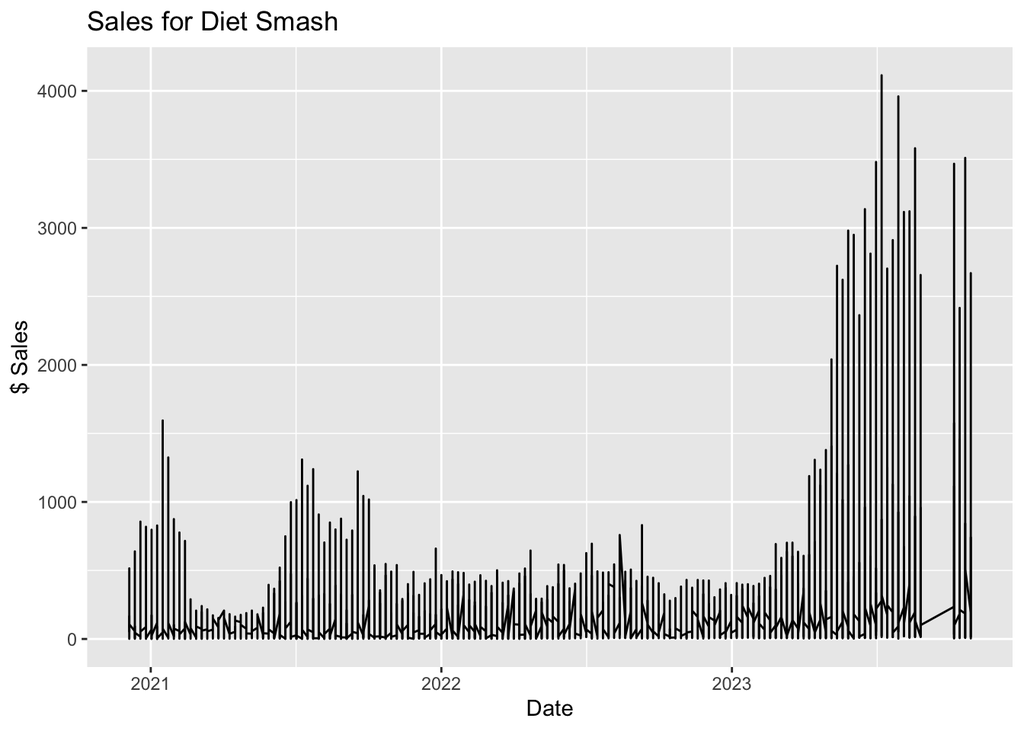

```r
#graph DOLLAR_SALES by DATE for BRAND == "DIET SMASH"
df %>%
  filter(BRAND == "DIET SMASH") %>%
  ggplot(aes(x = DATE, y = DOLLAR_SALES)) +
  geom_line() +
  labs(title = "Sales for Diet Smash",
       x = "Date",
       y = "$ Sales")
```

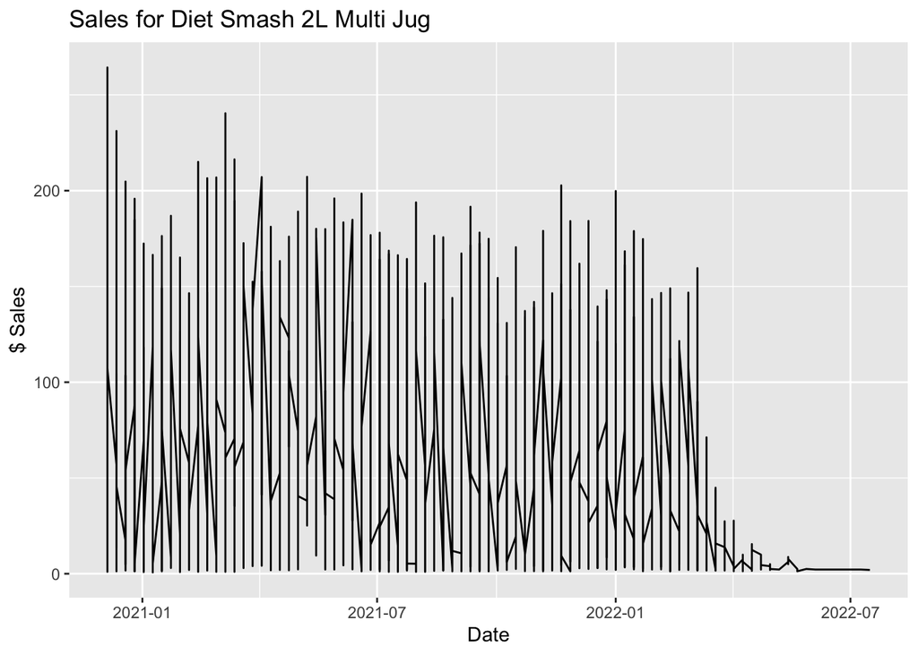

```r
#graph DOLLAR_SALES by DATE for BRAND == "DIET SMASH" - INNOVATION PACKAGE == "2L MULTI JUG"
df %>%
  filter(BRAND == "DIET SMASH", PACKAGE == "2L MULTI JUG") %>%
  ggplot(aes(x = DATE, y = DOLLAR_SALES)) +
  geom_line() +
  labs(title = "Sales for Diet Smash 2L Multi Jug",
       x = "Date",
       y = "$ Sales")
```

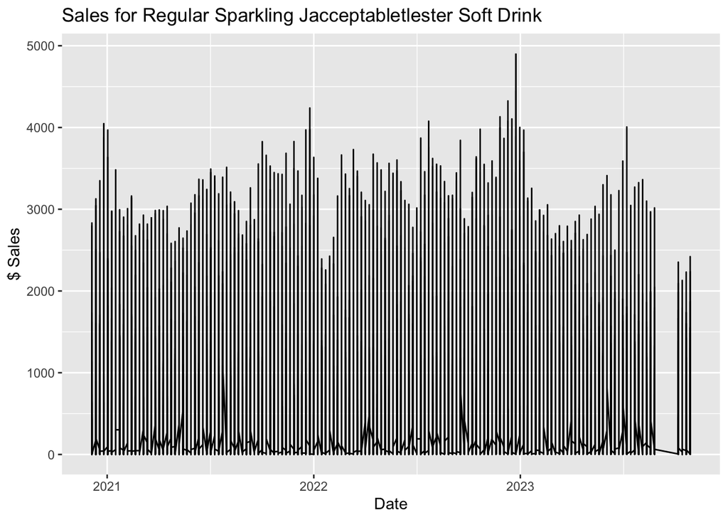

```r
#graph DOLLAR_SALES by DATE for BRAND == "SPARKLING JACCEPTABLETLESTER",
#CATEGORY == "SSD", CALORIC_SEGMENT == REGULAR
df %>%
  filter(BRAND == "SPARKLING JACCEPTABLETLESTER", CATEGORY == "SSD",
         CALORIC_SEGMENT == "1" ) %>%
  ggplot(aes(x = DATE, y = DOLLAR_SALES)) +
  geom_line() +
  labs(title = "Sales for Regular Sparkling Jacceptabletlester Soft Drink",
       x = "Date",
       y = "$ Sales")
```

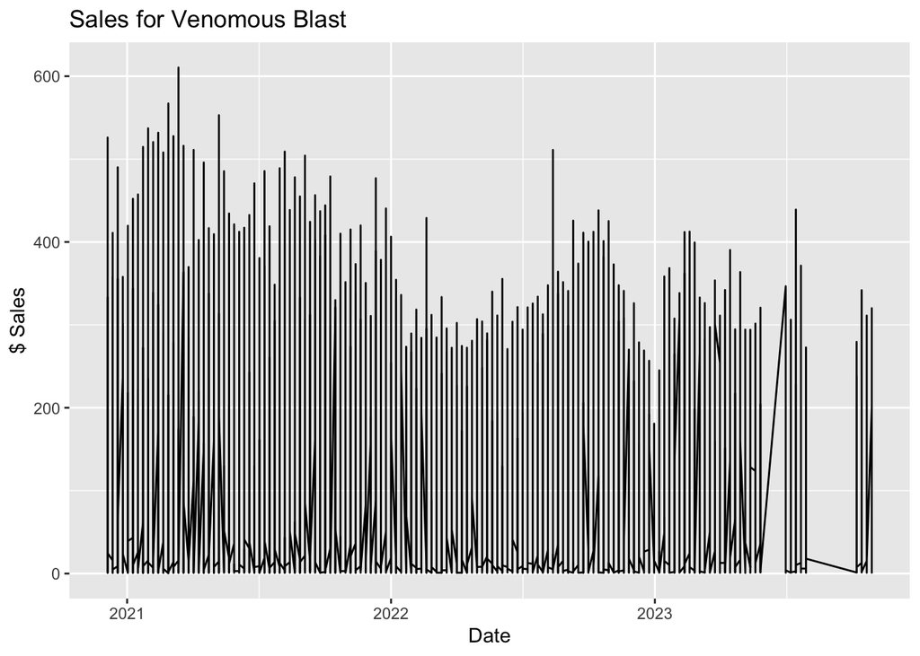

```r
#graph DOLLAR_SALES by DATE for BRAND == "VENOMOUS BLAST" and CALORIC_SEGMENT == DIET/LIGHT
df %>%
  filter(BRAND == "VENOMOUS BLAST", CALORIC_SEGMENT == 0) %>%
  ggplot(aes(x = DATE, y = DOLLAR_SALES)) +
  geom_line() +
  labs(title = "Sales for Venomous Blast",
       x = "Date",
       y = "$ Sales")
```

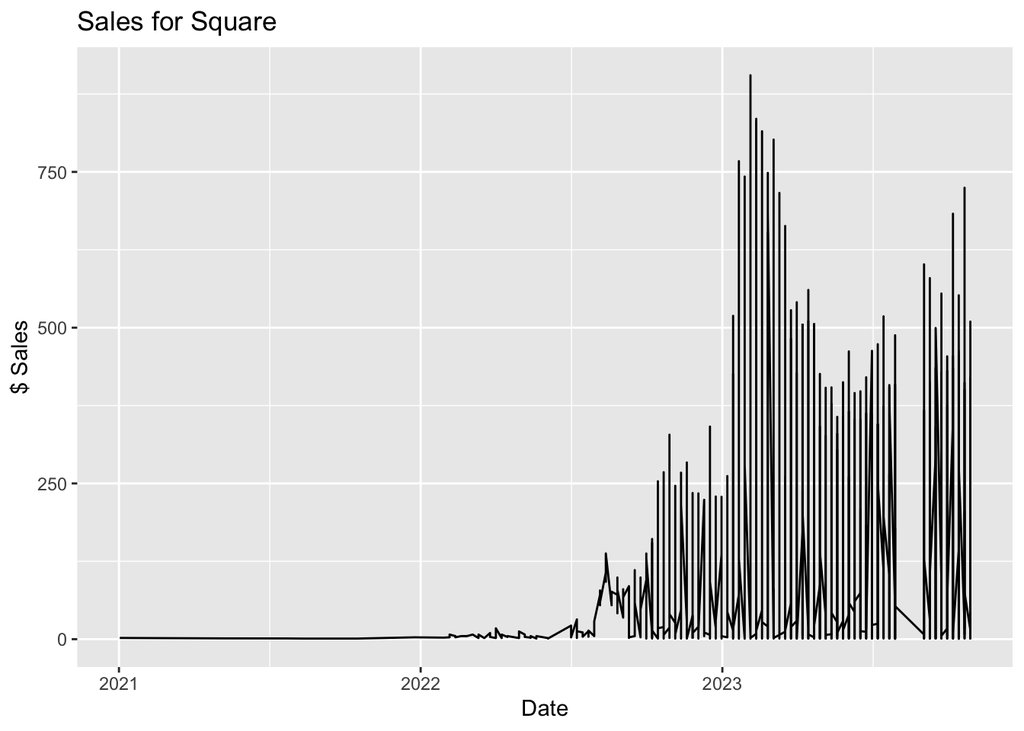

```r
#graph DOLLAR_SALES by DATE for BRAND == "SQUARE"
df %>%
  filter(BRAND == "SQUARE") %>%
  ggplot(aes(x = DATE, y = DOLLAR_SALES)) +
  geom_line() +
  labs(title = "Sales for Square",
       x = "Date",
       y = "$ Sales")
```

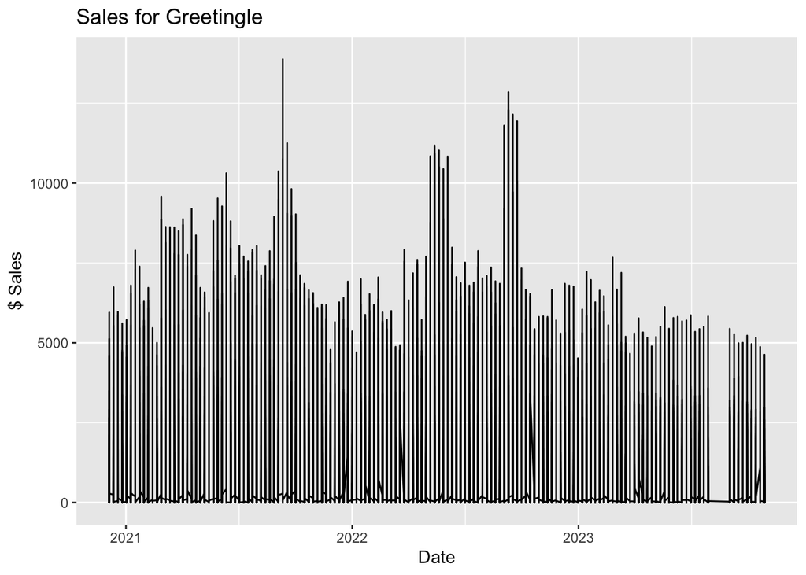

```r
#graph DOLLAR_SALES by DATE for BRAND == "GREETINGLE"
df %>%
  filter(BRAND == "GREETINGLE") %>%
  ggplot(aes(x = DATE, y = DOLLAR_SALES)) +
  geom_line() +
  labs(title = "Sales for Greetingle",
       x = "Date",
       y = "$ Sales")
```

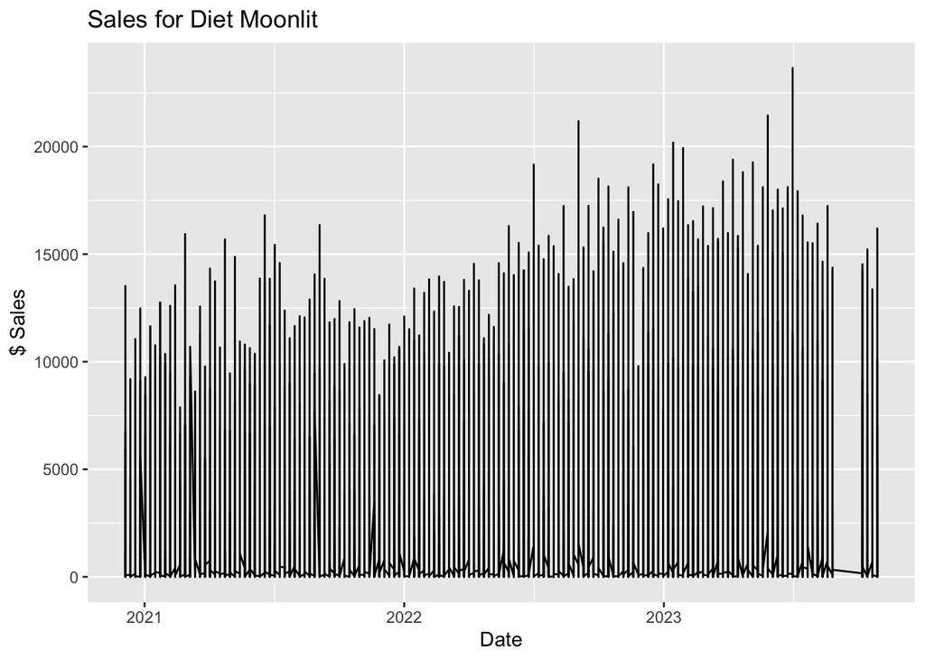

```r
#graph DOLLAR_SALES by DATE for BRAND == "DIET MOONLIT"
df %>%
  filter(BRAND == "DIET MOONLIT") %>%
  ggplot(aes(x = DATE, y = DOLLAR_SALES)) +
  geom_line() +
  labs(title = "Sales for Diet Moonlit",
       x = "Date",
       y = "$ Sales")
```

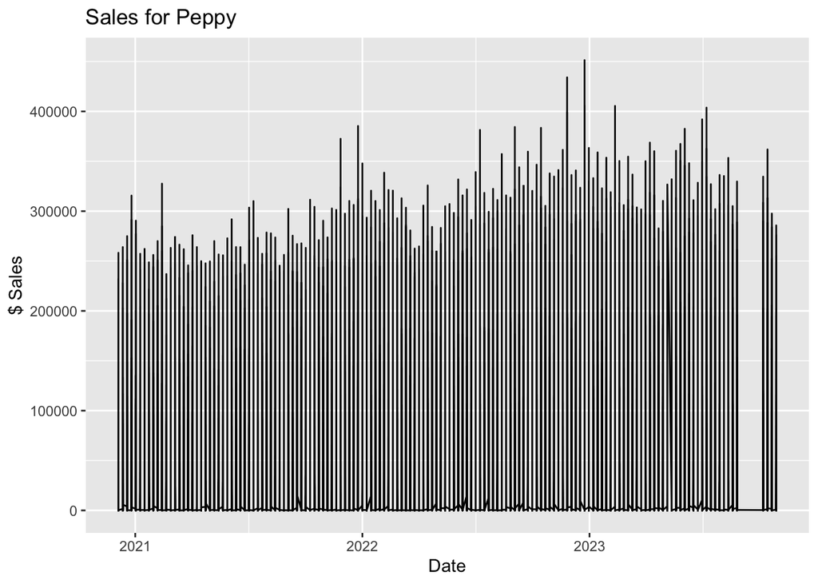

```r
#graph DOLLAR_SALES by DATE for BRAND == "PEPPY"
df %>%
  filter(BRAND == "PEPPY") %>%
  ggplot(aes(x = DATE, y = DOLLAR_SALES)) +
  geom_line() +
  labs(title = "Sales for Peppy",
       x = "Date",
       y = "$ Sales")
```

> Some seasonlity is observed in all drinks analyzed, with most including missing weeks and spikes. Are missing weeks, missing data, end of product lifecycle, or something else? The missing period seems common to several products analyzed.

```r
#What are the common gaps between DATE where there is no weekly data for BRAND == "DIET SMASH"
df %>%
  filter(BRAND == "DIET SMASH") %>%
  arrange(DATE) %>%
  mutate(DIFF = DATE - lag(DATE)) %>%
  filter(DIFF > 7) %>%
  count(DIFF) %>%
  arrange(desc(n)) %>%
  head(20)
```

```
##      DIFF n
## 1 42 days 1
```

```r
#What are the common gaps between DATE where there is no weekly data for BRAND == "DIET SMASH" and PACKAGE == "2L MULTI JUG"
df %>%
  filter(BRAND == "DIET SMASH", PACKAGE == "2L MULTI JUG") %>%
  arrange(DATE) %>%
  mutate(DIFF = DATE - lag(DATE)) %>%
  filter(DIFF > 7) %>%
  count(DIFF) %>%
  arrange(desc(n)) %>%
  head(20)
```

```
##      DIFF n
## 1 35 days 1
```

```r
#What are the common gaps between DATE where there is no weekly data for BRAND == "SPARKLING JACCEPTABLETLESTER",
#CATEGORY == "SSD", CALORIC_SEGMENT == REGULAR
df %>%
  filter(BRAND == "SPARKLING JACCEPTABLETLESTER", CATEGORY == "SSD",
         CALORIC_SEGMENT == 1) %>%
  arrange(DATE) %>%
  mutate(DIFF = DATE - lag(DATE)) %>%
  filter(DIFF > 7) %>%
  count(DIFF) %>%
  arrange(desc(n)) %>%
  head(20)
```

```
##      DIFF n
## 1 42 days 1
```

```r
#What are the common gaps between DATE where there is no weekly data for BRAND == "VENOMOUS BLAST" and CALORIC_SEGMENT == DIET/LIGHT
df %>%
  filter(BRAND == "VENOMOUS BLAST", CALORIC_SEGMENT == 0 ) %>%
  arrange(DATE) %>%
  mutate(DIFF = DATE - lag(DATE)) %>%
  filter(DIFF > 7) %>%
  count(DIFF) %>%
  arrange(desc(n)) %>%
  head(20)
```

```
##      DIFF n
## 1 35 days 1
## 2 70 days 1
```

```r
#What are the common gaps between DATE where there is no weekly data for BRAND == "SQUARE"
df %>%
  filter(BRAND == "SQUARE") %>%
  arrange(DATE) %>%
  mutate(DIFF = DATE - lag(DATE)) %>%
  filter(DIFF > 7) %>%
  count(DIFF) %>%
  arrange(desc(n)) %>%
  head(20)
```

```
##       DIFF n
## 1  35 days 3
## 2  14 days 2
## 3  28 days 2
## 4  21 days 1
## 5  70 days 1
## 6  77 days 1
## 7 126 days 1
```

```r
#What are the common gaps between DATE where there is no weekly data for BRAND == "GREETINGLE"
df %>%
  filter(BRAND == "GREETINGLE") %>%
  arrange(DATE) %>%
  mutate(DIFF = DATE - lag(DATE)) %>%
  filter(DIFF > 7) %>%
  count(DIFF) %>%
  arrange(desc(n)) %>%
  head(20)
```

```
##      DIFF n
## 1 35 days 1
```

```r
#What are the common gaps between DATE where there is no weekly data for BRAND == "DIET MOONLIT"
df %>%
  filter(BRAND == "DIET MOONLIT") %>%
  arrange(DATE) %>%
  mutate(DIFF = DATE - lag(DATE)) %>%
  filter(DIFF > 7) %>%
  count(DIFF) %>%
  arrange(desc(n)) %>%
  head(20)
```

```
##      DIFF n
## 1 42 days 1
```

```r
#What are the common gaps between DATE where there is no weekly data for BRAND == "PEPPY"
df %>%
  filter(BRAND == "PEPPY") %>%
  arrange(DATE) %>%
  mutate(DIFF = DATE - lag(DATE)) %>%
  filter(DIFF > 7) %>%
  count(DIFF) %>%
  arrange(desc(n)) %>%
  head(20)
```

```
##      DIFF n
## 1 42 days 1
```

> The “Diet Smash” brand has a gap in dates of 42 days. If packaging such as “2L Multi Jug” is added in, Diet Smash has a gap of 35 days. The “regular Sparkling Jacceptabletler brand in the ssd category” has a gap of 42 days. The “Venomous Blast” brand has 2 gaps, one of 35 days and the other of 70 days. The “Square” brand has 7 gap lengths in dates, with the most common of 35 days occuring 3 times, and the longest being 126 days. The “Greetingle” brand has a single gap length of 35 days. The “Diet Moonlit” has a single gap of 42 days. The “Peppy” brand has a single gap of 42 days. Further analysis should be done to ensure start/stop dates for tenure are accurate and that we are not missing weekly data.

```r
#most common launch DATE, end DATE, and TENURE of brand or package less than 6 months, or 26 weeks, in duration
df %>%
  group_by(BRAND, PACKAGE) %>%
  summarise(MIN_DATE = min(DATE),
            MAX_DATE = max(DATE),
            TENURE = MAX_DATE - MIN_DATE) %>%
  filter(TENURE < 26) %>%
  arrange(desc(TENURE))
```

```
## # A tibble: 145 × 5
## # Groups:   BRAND [102]
##    BRAND                                    PACKAGE MIN_DATE   MAX_DATE   TENURE
##    <fct>                                    <fct>   <date>     <date>     <drtn>
##  1 BARS                                     2L MUL… 2022-10-29 2022-11-19 21 da…
##  2 BUBBLE JOY ADVANTAGEOUS MOON             7.5SMA… 2022-02-26 2022-03-19 21 da…
##  3 JUICY SQUIRREL                           3L MUL… 2023-10-07 2023-10-28 21 da…
##  4 KOOL! READY-TO-GO                        20SMAL… 2023-10-07 2023-10-28 21 da…
##  5 KOOL! READY-TO-GO                        7.5SMA… 2023-10-07 2023-10-28 21 da…
##  6 KOOL! ZERO SUGAR READY-TO-GO             7.5SMA… 2023-10-07 2023-10-28 21 da…
##  7 ORANGE VANILLA BUBBLE JOY ADVANTAGEOUS … 12SMAL… 2021-06-12 2021-07-03 21 da…
##  8 PAPI ZERO SUGAR                          24SMAL… 2020-12-19 2021-01-09 21 da…
##  9 YAWN TROP                                20SMAL… 2023-10-07 2023-10-28 21 da…
## 10 DIET BUBBLE JOY ADVANTAGEOUS PLANT-BASE… 7.5SMA… 2023-08-05 2023-08-19 14 da…
## # ℹ 135 more rows
```

```r
#summarize top 10  brand or package less than 6 months, or 26 weeks, in duration for innovation set
df %>%
  group_by(BRAND, PACKAGE) %>%
  summarise(MIN_DATE = min(DATE),
            MAX_DATE = max(DATE),
            TENURE = MAX_DATE - MIN_DATE) %>%
  filter(TENURE < 26) %>%
  arrange(desc(TENURE)) %>%
  head(10)
```

```
## # A tibble: 10 × 5
## # Groups:   BRAND [9]
##    BRAND                                    PACKAGE MIN_DATE   MAX_DATE   TENURE
##    <fct>                                    <fct>   <date>     <date>     <drtn>
##  1 BARS                                     2L MUL… 2022-10-29 2022-11-19 21 da…
##  2 BUBBLE JOY ADVANTAGEOUS MOON             7.5SMA… 2022-02-26 2022-03-19 21 da…
##  3 JUICY SQUIRREL                           3L MUL… 2023-10-07 2023-10-28 21 da…
##  4 KOOL! READY-TO-GO                        20SMAL… 2023-10-07 2023-10-28 21 da…
##  5 KOOL! READY-TO-GO                        7.5SMA… 2023-10-07 2023-10-28 21 da…
##  6 KOOL! ZERO SUGAR READY-TO-GO             7.5SMA… 2023-10-07 2023-10-28 21 da…
##  7 ORANGE VANILLA BUBBLE JOY ADVANTAGEOUS … 12SMAL… 2021-06-12 2021-07-03 21 da…
##  8 PAPI ZERO SUGAR                          24SMAL… 2020-12-19 2021-01-09 21 da…
##  9 YAWN TROP                                20SMAL… 2023-10-07 2023-10-28 21 da…
## 10 DIET BUBBLE JOY ADVANTAGEOUS PLANT-BASE… 7.5SMA… 2023-08-05 2023-08-19 14 da…
```

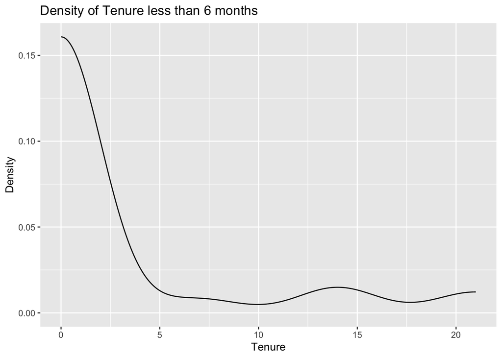

```r
#density plot of TENURE less than 6 months, or 26 weeks.
df %>%
  group_by(BRAND, PACKAGE) %>%
  summarise(MIN_DATE = min(DATE),
            MAX_DATE = max(DATE),
            TENURE = MAX_DATE - MIN_DATE) %>%
  filter(TENURE < 26) %>%
  ggplot(aes(x = TENURE)) +
  geom_density() +
  labs(title = "Density of Tenure less than 6 months",
       x = "Tenure",
       y = "Density")
```

# Summary and Results

> The analysis of Swire Coca-Cola’s sales data reveals several key insights. Initially, there were 59,725 missing values in the dataset, which were subsequently imputed using text data analysis, resulting in zero missing values. The dataset comprises 152 unique weeks, indicating weekly data availability for nearly three years without any missing weeks. Notably, there are 2 caloric segments, 5 categories, 8 manufacturers, 319 brands, 103 package types, and 3,692 unique item descriptions.

> Seasonal analysis reveals missing weeks and spikes across all drinks analyzed, raising questions about the cause, whether due to missing data or product lifecycle endings. Further investigation is warranted to ensure accurate start and stop dates for product tenures, particularly for brands with gaps in dates.

> In summary, the analysis provides valuable insights into Swire Coca-Cola’s sales data, highlighting key trends, product characteristics, and areas for further investigation to optimize forecasting and product launch strategies.

```r
stopImplicitCluster()
```